# Estadística Avanzada: A2 - Analítica descriptiva e inferencial

Autor: Raúl Vicente Ferrer

Noviembre 2021

```r
# https://cran.r-project.org/web/packages/ggplot2/index.html
if (!require('ggplot2')) install.packages('ggplot2'); library('ggplot2')
# https://cran.r-project.org/web/packages/dplyr/index.html
if (!require('dplyr')) install.packages('dplyr'); library('dplyr')
# https://cran.r-project.org/web/packages/dplyr/index.html
if (!require('knitr')) install.packages('knitr'); library('knitr')
# https://cran.r-project.org/web/packages/dplyr/index.html
if (!require('kableExtra')) install.packages('kableExtra'); library('kableExtra')
# https://cran.r-project.org/web/packages/nortest/index.html
if (!require('nortest')) install.packages('nortest'); library('nortest')
```

# 1 Lectura del fichero y preparación de los datos

```r
claim <- read.csv("./train_clean2.csv", header=TRUE)
```

```r
str(claim)
```

```
## 'data.frame':    50526 obs. of  17 variables:
##  $ X                 : int  1 2 3 4 5 6 7 9 10 11 ...
##  $ ClaimNumber       : chr  "WC8285054" "WC6982224" "WC5481426" "WC9775968" ...
##  $ DateTimeOfAccident: chr  "2002-04-09T07:00:00Z" "1999-01-07T11:00:00Z" "1996-03-25T00:00:00Z" "2005-06-22T13:00:00Z" ...
##  $ DateReported      : chr  "2002-07-05T00:00:00Z" "1999-01-20T00:00:00Z" "1996-04-14T00:00:00Z" "2005-07-22T00:00:00Z" ...
##  $ Age               : int  48 43 30 41 36 50 39 49 30 20 ...
##  $ Gender            : chr  "M" "F" "M" "M" ...
##  $ MaritalStatus     : chr  "M" "M" "M" "M" ...
##  $ DependentChildren : int  0 0 0 0 0 0 0 0 0 0 ...
##  $ DependentsOther   : int  0 0 0 0 0 0 0 0 0 0 ...
##  $ WeeklyWages       : num  500 509 709 555 377 ...
##  $ PartTimeFullTime  : chr  "F" "F" "F" "F" ...
##  $ HoursWeek         : num  38 37.5 38 38 38 38 38 38 37 40 ...
##  $ DaysWeek          : int  5 5 5 5 5 5 5 5 5 5 ...
##  $ ClaimDescription  : chr  "LIFTING TYRE INJURY TO RIGHT ARM AND WRIST INJURY" "STEPPED AROUND CRATES AND TRUCK TRAY FRACTURE LEFT FOREARM" "CUT ON SHARP EDGE CUT LEFT THUMB" "DIGGING LOWER BACK LOWER BACK STRAIN" ...
##  $ IniCost           : int  1500 5500 1700 15000 2800 500 500 925 1500 3500 ...
##  $ UltCost           : int  4303 6106 2099 16283 3772 747 187 1253 1215 4502 ...
##  $ Time              : int  87 13 20 30 29 80 10 33 15 11 ...
```

```r
summary(claim)
```

```
##        X         ClaimNumber        DateTimeOfAccident DateReported
##  Min.   :    1   Length:50526       Length:50526       Length:50526
##  1st Qu.:13515   Class :character   Class :character   Class :character
##  Median :27007   Mode  :character   Mode  :character   Mode  :character
##  Mean   :27004
##  3rd Qu.:40480
##  Max.   :54000
##       Age           Gender          MaritalStatus      DependentChildren
##  Min.   :13.00   Length:50526       Length:50526       Min.   :0.000
##  1st Qu.:24.00   Class :character   Class :character   1st Qu.:0.000
##  Median :32.00   Mode  :character   Mode  :character   Median :0.000
##  Mean   :34.04                                         Mean   :0.123
##  3rd Qu.:43.00                                         3rd Qu.:0.000
##  Max.   :81.00                                         Max.   :8.000
##  DependentsOther    WeeklyWages      PartTimeFullTime     HoursWeek
##  Min.   :0.00000   Min.   :   6.81   Length:50526       Min.   : 1.00
##  1st Qu.:0.00000   1st Qu.: 238.71   Class :character   1st Qu.:38.00
##  Median :0.00000   Median : 408.50   Mode  :character   Median :38.00
##  Mean   :0.01043   Mean   : 433.78                      Mean   :37.36
##  3rd Qu.:0.00000   3rd Qu.: 513.00                      3rd Qu.:40.00
##  Max.   :5.00000   Max.   :7497.00                      Max.   :93.00
##     DaysWeek     ClaimDescription      IniCost           UltCost
##  Min.   :1.000   Length:50526       Min.   :      1   Min.   :     6
##  1st Qu.:5.000   Class :character   1st Qu.:    735   1st Qu.:  1183
##  Median :5.000   Mode  :character   Median :   2000   Median :  3291
##  Mean   :4.906                      Mean   :   7988   Mean   : 10148
##  3rd Qu.:5.000                      3rd Qu.:   9500   3rd Qu.:  9226
##  Max.   :7.000                      Max.   :2000000   Max.   :492515
##       Time
##  Min.   :   0.00
##  1st Qu.:  14.00
##  Median :  22.00
##  Mean   :  39.05
##  3rd Qu.:  41.00
##  Max.   :1095.00
```

# 2 Coste de los siniestros

## 2.1 Análisis visual

- Diagrama de caja de la distribución de la variable ‘UltCost’:

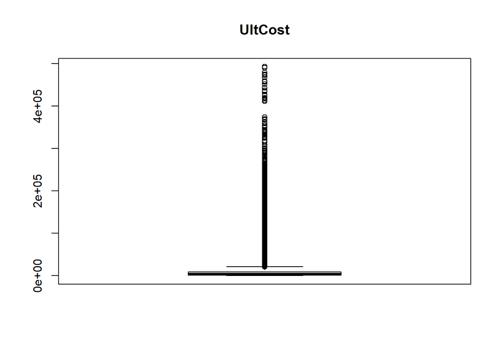

```r
boxplot(claim$UltCost, main="UltCost")
```

- Transformación a escala logarítmica de la variable ‘UltCost’ y diagrama de caja:

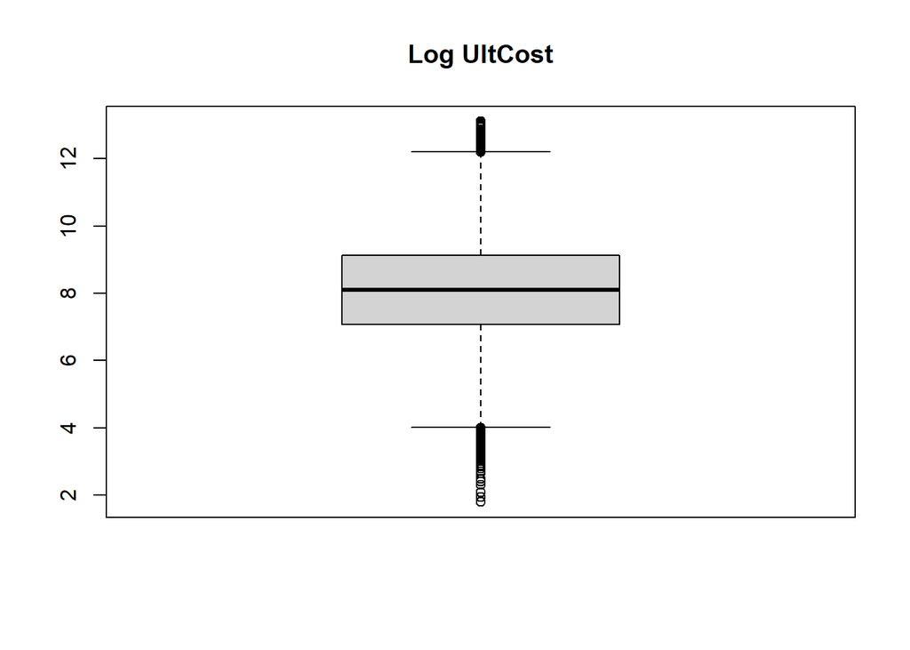

```r
logUltCost <- log(claim$UltCost)
boxplot(logUltCost, main="Log UltCost")
```

## 2.2 Comprobación de normalidad

- Inspección visual de la normalidad de la variable ‘UltCost’:

Un gráfico Q-Q normal nos muestra como se aproximan estos datos a una distribución normal:

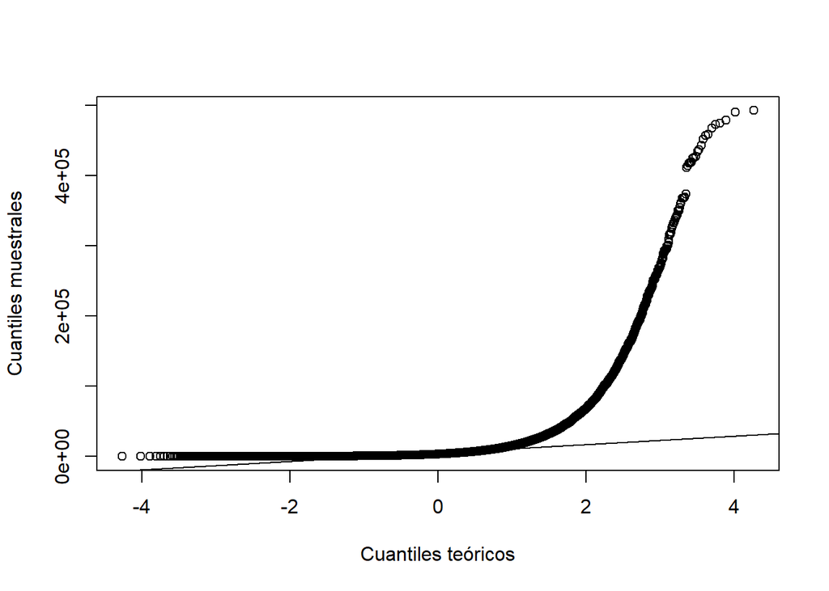

```r
qqnorm(claim$UltCost, main = "", xlab = "Cuantiles teóricos", ylab = "Cuantiles muestrales")
qqline(claim$UltCost)
```

Se observa que no siguen una distribución normal. Esto es más fácil de visualizar con un histograma de densidad y una curva de distribución normal superpuesta:

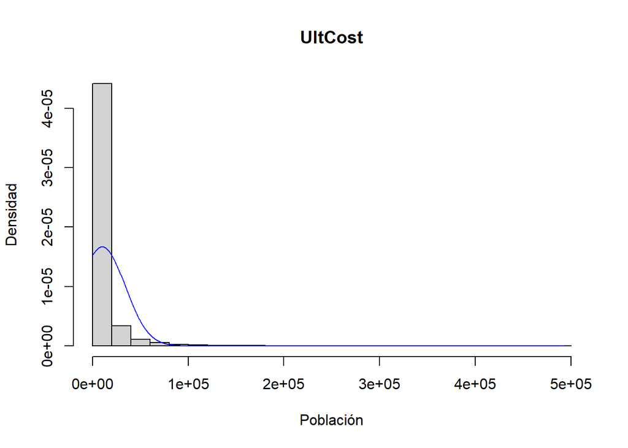

```r
hist(claim$UltCost, probability = TRUE, main = "UltCost", xlab = "Población", ylab = "Densidad",  breaks=20)
x   <- seq(min(claim$UltCost), max(claim$UltCost), length = 1000)
y <- dnorm(x, mean(claim$UltCost), sd(claim$UltCost))
lines(x, y, col = "blue")
```

- Contraste de normalidad de Lilliefors:

```r
lillie.test(claim$UltCost)
```

```
##
##  Lilliefors (Kolmogorov-Smirnov) normality test
##
## data:  claim$UltCost
## D = 0.33597, p-value < 2.2e-16
```

Como p-value es menor de 0.05 se rechaza la hipótesis de normalidad.

- Inspección visual y contraste de la normalidad de la variable ‘UltCost’ en escala logarítmica:

Un gráfico Q-Q normal nos muestra como se aproximan estos datos a una distribución normal:

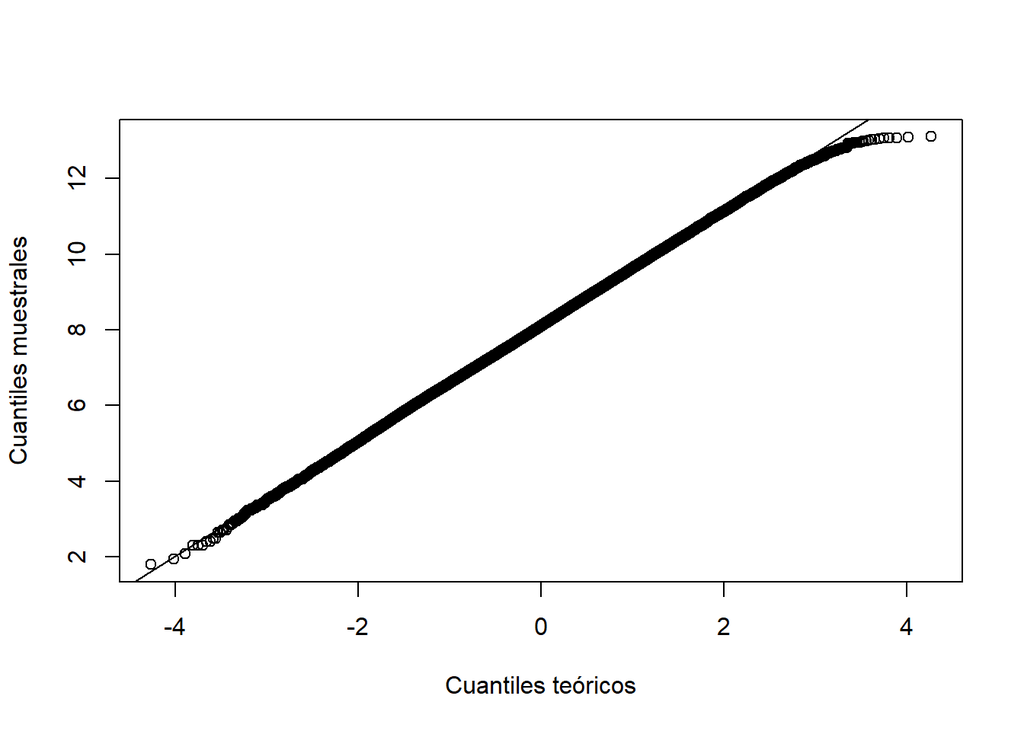

```r
qqnorm(logUltCost, main = "", xlab = "Cuantiles teóricos", ylab = "Cuantiles muestrales")
qqline(logUltCost)
```

Se observa que siguen una distribución normal. Esto es más fácil de visualizar con un histograma de densidad y una curva de distribución normal superpuesta:

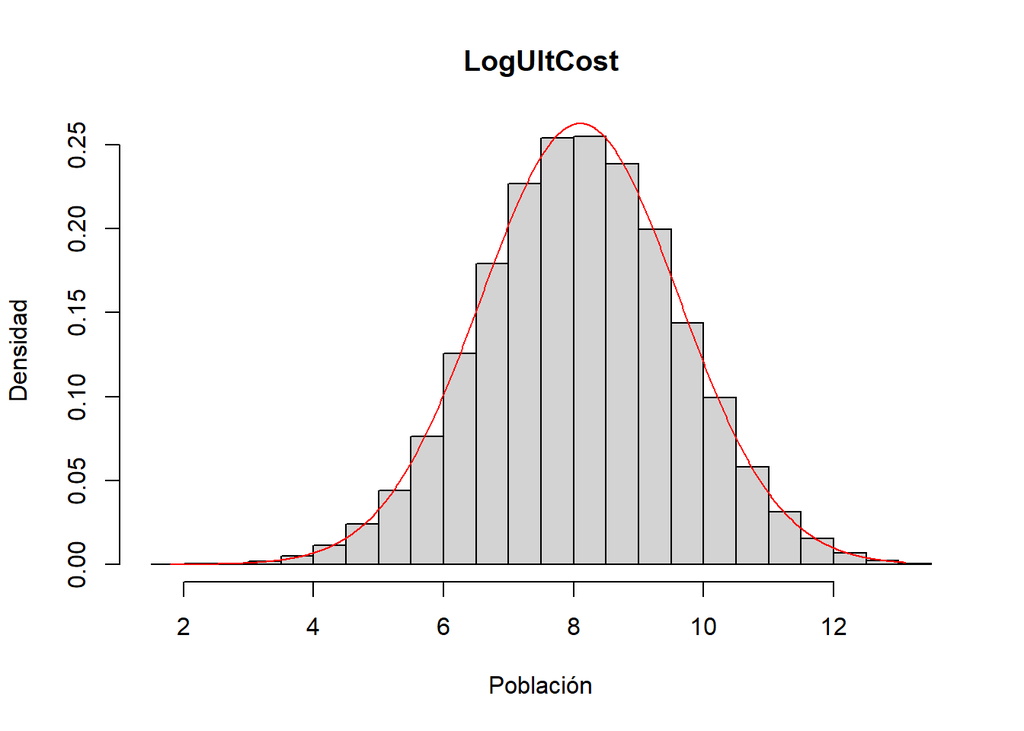

```r
hist(logUltCost, probability = TRUE, main = "LogUltCost", xlab = "Población", ylab = "Densidad",  breaks=20)
x   <- seq(min(logUltCost), max(logUltCost), length = 1000)
y <- dnorm(x, mean(logUltCost), sd(logUltCost))
lines(x, y, col = "red")
```

Contraste de normalidad de Lilliefors:

```r
lillie.test(logUltCost)
```

```
##
##  Lilliefors (Kolmogorov-Smirnov) normality test
##
## data:  logUltCost
## D = 0.0029142, p-value = 0.375
```

Como p-value es mayor de 0.05 se acepta la hipótesis de normalidad.

## 2.3 Intervalo de confianza de la media poblaciona de la variable ‘UltCost’

- Cálculo manual del intervalo de confianza al 95% de la media poblacional de la variable ‘UltCost’:

Intervalo de confianza:

```r
n <- nrow(claim)
alpha <- (1-0.95)
SE <- sd(claim$UltCost) / sqrt(n)
t <- qnorm(alpha/2, lower.tail=FALSE)
L <- mean(claim$UltCost) - t*SE
U <- mean(claim$UltCost) + t*SE
c(L,U)
```

```
## [1]  9938.86 10356.47
```

- ¿Podemos asumir la hipótesis de normalidad para el cálculo del intervalo de confianza sobre la media muestral del coste en escala original?

El Teorema del Límite Central (TLC) establece que el contraste de hipótesis sobre la media de una muestra se aproxima a una distribución normal aunque la población original no siga una distribución normal, siempre que el tamaño de la muestra sea suficientemente grande, es decir, mayor de 30. Así que, en este caso, se cumple el TLC y por o tanto podemos asumir la hipótesis de normalidad para el cálculo del intervalo de confianza sobre la media muestral.

- Interpretación del intervalo de confianza:

Si obtenemos infinitas muestras del conjunto de datos, el 95% de los intervalos de confianza calculados a partir de esas muestras contendrían el valor medio del coste.

# 3 Coste inicial y final de los siniestros

¿Podemos aceptar que no hay diferencias entre IniCost y UltCost?

## 3.1 Justificación del test a aplicar

Por el teorema del límite central, podemos asumir normalidad y se desea realizar un test sobre la media.

Como no se conoce la varianza de la población aplicamos la distribución t,

Se trata de un contraste de dos muestras emparejadas sobre la media con varianzas desconocidas y bilateral.Ya que queremos comparar dos muestras que están univocamente relacionadas.

## 3.2 Hipótesis nula y alternativa

$H_0: µ_d = 0$

$H_1: µ_d \neq 0$

## 3.3 Cálculos

```r
testhipotesis <- function (m1, m2, NConf=0.95, paired=TRUE, var.equal=TRUE, alternative="two.sided") {
  alpha <- (1-NConf)
  mean1 <- mean(m1)
  n1 <- length(m1)
  sd1 <- sd(m1)
  mean2 <- mean(m2)
  n2 <- length(m2)
  sd2 <- sd(m2)
  diff <- m1-m2
  nD <- length(diff)
  meanD <- mean(diff)
  sD <- sd(diff)
  #paired==TRUE
  if (paired==TRUE){
    t <- abs(meanD/(sD/sqrt(nD)))
    #alternative=="two.sided"
    if (alternative=="two.sided"){
      tcritical <- qt(alpha/2, df=nD-1, lower.tail=FALSE)
      pvalue <- pt(abs(t), df=nD-1, lower.tail=FALSE)*2
    }
    #alternative=="less"
    else if (alternative=="less"){
      tcritical <- qt(alpha, df=nD-1, lower.tail=TRUE)
      pvalue <- pt(abs(t), df=nD-1, lower.tail=TRUE)
    }
    #alternative=="greater"
    else{
      tcritical <- qt(alpha, df=nD-1, lower.tail=FALSE)
      pvalue <- pt(abs(t), df=nD-1, lower.tail=FALSE)
    }
    result <- data.frame(t, tcritical, pvalue)
    result %>% kable() %>% kable_styling()
  }

  #paired==FALSE
  else{
    #var.equal==TRUE
    if (var.equal==TRUE){
      s <- sqrt(((n1-1)*sd1^2+(n2-1)*sd2^2)/(n1+n2-2))
      Sb <- s*sqrt(1/n1 + 1/n2)
      df <- n1+n2-2
    }
    #var.equal==FALSE
    else{
      Sb <- sqrt(sd1^2/n1 + sd2^2/n2)
      df <- ((sd1^2/n1 + sd2^2/n2)^2)/((sd1^2/n1)^2/(n1-1)+(sd2^2/n2)^2/(n2-1))
    }
    t <- abs((mean1-mean2)/Sb)
    #alternative=="two.sided"
    if (alternative=="two.sided"){
      tcritical <- qt(alpha/2, df, lower.tail=FALSE)
      pvalue <- pt(abs(t), df, lower.tail=FALSE )*2
    }
    #alternative=="less"
    else if (alternative=="less"){
      tcritical <- qt(alpha, df, lower.tail=TRUE)
      pvalue <- pt(t, df, lower.tail=TRUE)
    }
    #alternative=="greater"
    else{
      tcritical <- qt(alpha, df, lower.tail=FALSE)
      pvalue <- pt(t, df, lower.tail=FALSE)
    }
    result <- data.frame(t, tcritical, pvalue)
    result %>% kable() %>% kable_styling()
  }
  return(result)
}

result3<-testhipotesis(claim$UltCost, claim$IniCost, paired=TRUE, var.equal=FALSE, alternative = "two.sided")
result3
```

```
##          t tcritical       pvalue
## 1 20.80108  1.960011 1.067535e-95
```

## 3.4 Conclusión

El valor crítico para un nivel de confianza del 95% es 1.960011 y el valor observado es 20.80108. Por lo tanto, nos encontramos en la zona de rechazo de la hipótesis nula y podemos concluir que hay diferencias entre IniCost y UltCost. Se concluye lo mismo con el valor p, que da un valor de 1.067535 × 10<sup>−95</sup>, muy inferior a alpha=0.05.

## 3.5 Comprobación

```r
t.test(claim$UltCost, claim$IniCost, var.equal=FALSE, paired=TRUE, alternative = "two.sided")
```

```
##
##  Paired t-test
##
## data:  claim$UltCost and claim$IniCost
## t = 20.801, df = 50525, p-value < 2.2e-16
## alternative hypothesis: true difference in means is not equal to 0
## 95 percent confidence interval:
##  1955.884 2362.820
## sample estimates:
## mean of the differences
##                2159.352
```

Los valores coinciden.

# 4 Diferencia de salario según género

## 4.1 Análisis visual

- Diagrama de caja de la distribución de la variable WeeklyWages según el género

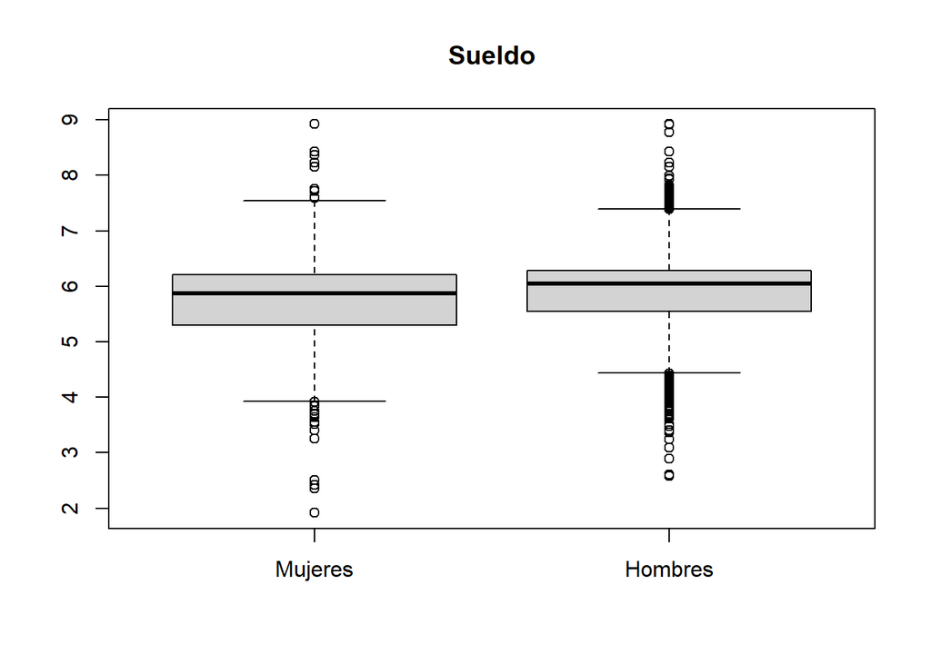

```r
Mujeres <- claim[claim$Gender=="F",]
Hombres <- claim[claim$Gender=="M",]

boxplot(log(Mujeres$WeeklyWages), log(Hombres$WeeklyWages), names=c("Mujeres","Hombres"), main="Sueldo" )
```

## 4.2 Interpretación

Se observan pequeñas diferencias entre sueldos, el límite inferior de los sueldos es menor en mujeres, pero el superior parece ser superior. Es necesario recurrir a un contraste de hipótesis para confirmar si estas diferencias observadas son significativas.

## 4.3 Hipótesis nula y alternativa

¿Podemos aceptar que los hombres cobran más que las mujeres en promedio a la semana?

$H_0: µ_H = µ_M$

$H_1: µ_H > µ_M$

## 4.4 Justificación del test a aplicar

Por el teorema del límite central, podemos asumir normalidad y se desea realizar un test sobre la media.

Como no se conoce la varianza de la población aplicamos la distribución t,

Comprobamos igualdad de varianzas:

```r
testvar <- function (m1, m2, NConf=0.95) {
  alpha <- (1-NConf)
  mean1 <- mean(m1)
  n1 <- length(m1)
  sd1 <- sd(m1)
  mean2 <- mean(m2)
  n2 <- length(m2)
  sd2 <- sd(m2)

  f <- sd1^2/sd2^2
  fcritL <- qf(alpha/2, df1=n1-1, df2=n2-2)
  fcritU <- qf(1-alpha/2, df1=n1-1, df2=n2-2)
  pvalue <- min(pf(f, df1=n1-1, df2=n2-2, lower.tail=FALSE), pf(f, df1=n1-1, df2=n2-2))*2

  result <- data.frame(f, fcritL, fcritU, pvalue)
  result %>% kable() %>% kable_styling()

  return(result)
}
testvar(Hombres$WeeklyWages, Mujeres$WeeklyWages, NConf=0.95)
```

```
##          f    fcritL   fcritU        pvalue
## 1 1.408441 0.9712333 1.029861 5.030028e-109
```

```r
var.test(Hombres$WeeklyWages, Mujeres$WeeklyWages)
```

```
##
##  F test to compare two variances
##
## data:  Hombres$WeeklyWages and Mujeres$WeeklyWages
## F = 1.4084, num df = 38903, denom df = 11619, p-value < 2.2e-16
## alternative hypothesis: true ratio of variances is not equal to 1
## 95 percent confidence interval:
##  1.367605 1.450156
## sample estimates:
## ratio of variances
##           1.408441
```

p<0.001, por lo que descartamos igualdad de varianzas.

Se trata de un contraste de dos muestras independientes sobre la media con varianzas desconocidas y unilateral por la derecha.

## 4.5 Cálculos

Ya se implementó una función en el ejercicio 3 que se puede utilizar en este caso también, en lugar de repetir el código. El resultado que arroja es:

```r
result4<-testhipotesis(Hombres$WeeklyWages, Mujeres$WeeklyWages, paired=FALSE, var.equal=FALSE, alternative = "greater")
result4
```

```
##         t tcritical        pvalue
## 1 28.8127  1.644922 1.437086e-179
```

## 4.6 Conclusión

El valor crítico para un nivel de confianza del 95% es 1.644922 y el valor observado es 28.8127. Por lo tanto, nos encontramos en la zona de rechazo de la hipótesis nula y podemos concluir que hay diferencias entre los salarios de hombres y mujeres. Se concluye lo mismo con el valor p, que da un valor de 1.437086 × 10<sup>−179</sup>, muy inferior a alpha=0.05. Así que estamos en la zona a favor de la hipótesis alternativa y podemos aceptar que los hombres cobran más que las mujeres en promedio a la semana.

## 4.7 Comprobación

```r
t.test(Hombres$WeeklyWages, Mujeres$WeeklyWages, var.equal=FALSE, paired=FALSE, alternative = "greater")
```

```
##
##  Welch Two Sample t-test
##
## data:  Hombres$WeeklyWages and Mujeres$WeeklyWages
## t = 28.813, df = 22274, p-value < 2.2e-16
## alternative hypothesis: true difference in means is greater than 0
## 95 percent confidence interval:
##  64.18029      Inf
## sample estimates:
## mean of x mean of y
##  449.4311  381.3649
```

Se obtiene el mismo resultado.

# 5 Salario semanal (II)

¿Podemos aceptar que los hombres cobran al menos 50 euros más que las mujeres en promedio a la semana?

## 5.1 Hipótesis nula y alternativa

$H_0: µ_H - µ_M = 50$

$H_1: µ_H - µ_M > 50$

## 5.2 Justificación del test a aplicar

Por el teorema del límite central, podemos asumir normalidad y se desea realizar un test sobre la media.

Como no se conoce la varianza de la población aplicamos la distribución t,

Comprobamos igualdad de varianzas:

```r
testvar(Hombres$WeeklyWages-50, Mujeres$WeeklyWages, NConf=0.95)
```

```
##          f    fcritL   fcritU        pvalue
## 1 1.408441 0.9712333 1.029861 5.030028e-109
```

```r
var.test(Hombres$WeeklyWages-50, Mujeres$WeeklyWages)
```

```
##
##  F test to compare two variances
##
## data:  Hombres$WeeklyWages - 50 and Mujeres$WeeklyWages
## F = 1.4084, num df = 38903, denom df = 11619, p-value < 2.2e-16
## alternative hypothesis: true ratio of variances is not equal to 1
## 95 percent confidence interval:
##  1.367605 1.450156
## sample estimates:
## ratio of variances
##           1.408441
```

p<0.001, por lo que descartamos igualdad de varianzas.

Se trata de un contraste de dos muestras independientes sobre la media con varianzas desconocidas y unilateral por la derecha.

## 5.3 Cálculos

```r
result5<-testhipotesis(Hombres$WeeklyWages-50, Mujeres$WeeklyWages, paired=FALSE, var.equal=FALSE, alternative = "greater")
result5
```

```
##          t tcritical       pvalue
## 1 7.647497  1.644922 1.066063e-14
```

## 5.4 Conclusión

El valor crítico para un nivel de confianza del 95% es 1.644922 y el valor observado es 7.647497. Por lo tanto, nos encontramos en la zona de rechazo de la hipótesis nula y podemos concluir que la diferencia que hay entre los salarios de hombres y mujeres es mayor de 50. Se concluye lo mismo con el valor p, que da un valor de 1.066063 × 10<sup>−14</sup>, muy inferior a alpha=0.05. Así que estamos en la zona a favor de la hipótesis alternativa y podemos aceptar que los hombres cobran al menos 50 euros más que las mujeres en promedio a la semana.

## 5.5 Comprobación

```r
t.test(Hombres$WeeklyWages-50, Mujeres$WeeklyWages, var.equal=FALSE, paired=FALSE, alternative = "greater")
```

```
##
##  Welch Two Sample t-test
##
## data:  Hombres$WeeklyWages - 50 and Mujeres$WeeklyWages
## t = 7.6475, df = 22274, p-value = 1.066e-14
## alternative hypothesis: true difference in means is greater than 0
## 95 percent confidence interval:
##  14.18029      Inf
## sample estimates:
## mean of x mean of y
##  399.4311  381.3649
```

Se obtiene el mismo resultado.

# 6 Diferencia de jornada según género

## 6.1 Análisis visual

- Diagrama de barras con los porcentajes de cada categoría de la variable ParTimeFullTime según el género

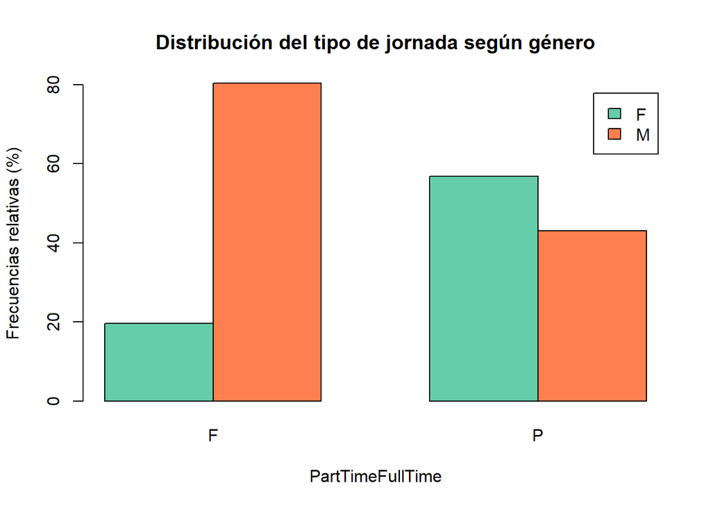

```r
claim2 <- claim[!(claim$Gender=="U"),]
claim2$Gender <- as.factor(claim2$Gender)
claim2$PartTimeFullTime <- as.factor(claim2$PartTimeFullTime)
tab <- table(claim2$Gender, claim2$PartTimeFullTime)
tab2 <- prop.table(tab, 2)
barplot(tab2*100,
        main = "Distribución del tipo de jornada según género",
        ylab = "Frecuencias relativas (%)",
        xlab = "PartTimeFullTime",
        legend = T,
        col = c("aquamarine3", "coral"),
        beside = TRUE)
```

## 6.2 Interpretación

El número total de hombres que trabaja a tiempo completo es muy superior que número total de mujeres, y ocurre al revés para el tiempo parcial. Pero el número de registros masculinos es muy superior al de mujeres, así que lo que habría que estudiar es la proporción de cada grupo.

## 6.3 Hipótesis y alternativa

¿La proporción de personas que trabajan a tiempo completo es diferente para hombres que para mujeres?

$H_0: p_H = p_M$

$H_1: p_H \neq p_M$

## 6.4 Tipo de test

Se trata de un contraste de dos muestras independientes sobre la proporción. Ya que necesitamos plantear un contraste entre proporciones. Usaremos un nivel de confianza del 95% ya que no se especifica otro en el enunciado.

## 6.5 Cálculos

```r
alpha = 1-0.95
n1 <- length(Hombres$PartTimeFullTime)
n2 <- length(Mujeres$PartTimeFullTime)
p1 <- sum(Hombres$PartTimeFullTime=='F')/n1
p2 <- sum(Mujeres$PartTimeFullTime=='F')/n2
p <- (n1*p1+n2*p2)/(n1+n2)
z <- (p1-p2)/(sqrt(p*(1-p)*(1/n1+1/n2)))
zcritical <- qnorm(alpha/2)
pvalue<- pnorm(abs(z), lower.tail=FALSE)*2
result6 <- data.frame(z, zcritical, pvalue)
result6
```

```
##         z zcritical pvalue
## 1 57.3423 -1.959964      0
```

## 6.7 Comprobación

```r
success <- c( p1*n1, p2*n2)
nn <- c(n1,n2)
prop.test(success, nn, alternative="two.sided", correct=FALSE)
```

```
##
##  2-sample test for equality of proportions without continuity
##  correction
##
## data:  success out of nn
## X-squared = 3288.1, df = 1, p-value < 2.2e-16
## alternative hypothesis: two.sided
## 95 percent confidence interval:
##  0.1666030 0.1824183
## sample estimates:
##    prop 1    prop 2
## 0.9489513 0.7744406
```

# 7 Salario por hora

¿Podemos afirmar que los hombres cobran más que las mujeres por hora trabajada?

## 7.1 Hipótesis nula y alternativa

$H_0: µ_H = µ_M$

$H_1: µ_H > µ_M$

## 7.2 Tipo de test

Por el teorema del límite central, podemos asumir normalidad y se desea realizar un test sobre la media.

Como no se conoce la varianza de la población aplicamos la distribución t,

Comprobamos igualdad de varianzas:

```r
claim3 <- claim
claim3$HourlyWages = claim3$WeeklyWages/claim3$HoursWeek
Mujeres <- claim3[claim3$Gender=="F",]
Hombres <- claim3[claim3$Gender=="M",]
testvar(Hombres$HourlyWages, Mujeres$HourlyWages, NConf=0.95)
```

```
##           f    fcritL   fcritU        pvalue
## 1 0.6239975 0.9712333 1.029861 2.924798e-236
```

```r
var.test(Hombres$HourlyWages, Mujeres$HourlyWages)
```

```
##
##  F test to compare two variances
##
## data:  Hombres$HourlyWages and Mujeres$HourlyWages
## F = 0.624, num df = 38903, denom df = 11619, p-value < 2.2e-16
## alternative hypothesis: true ratio of variances is not equal to 1
## 95 percent confidence interval:
##  0.6059053 0.6424789
## sample estimates:
## ratio of variances
##          0.6239975
```

p<0.001, por lo que descartamos igualdad de varianzas.

Por lo tanto, el test a realizar es un contraste de dos muestras independientes sobre la media con varianzas desconocidas.

## 7.3 Cálculos

```r
result7<-testhipotesis(Hombres$HourlyWages, Mujeres$HourlyWages, paired=FALSE, var.equal=FALSE, alternative = "greater")
result7
```

```
##           t tcritical   pvalue
## 1 0.7098522  1.644948 0.238903
```

## 7.4 Conclusión

El valor crítico para un nivel de confianza del 95% es 1.644948 y el valor observado es 0.7098522. Por lo tanto, nos encontramos en la zona de aceptación de la hipótesis nula y podemos concluir que los hombres no cobran más que las mujeres por hora trabajada. Se concluye lo mismo con el valor p, que da un valor de 0.238903, superior a alpha=0.05.

## 7.5 Comprobación

```r
t.test(Hombres$HourlyWages, Mujeres$HourlyWages, paired=FALSE, var.equal=FALSE, alternative = "greater")
```

```
##
##  Welch Two Sample t-test
##
## data:  Hombres$HourlyWages and Mujeres$HourlyWages
## t = 0.70985, df = 16186, p-value = 0.2389
## alternative hypothesis: true difference in means is greater than 0
## 95 percent confidence interval:
##  -0.08790322         Inf
## sample estimates:
## mean of x mean of y
##  11.83031  11.76358
```

Los valores coinciden.

# 8 Resumen ejecutivo

- Si obtenemos infinitas muestras del conjunto de datos, el 95% de los intervalos de confianza calculados a partir de esas muestras contendrían el valor medio de la variable (UltCost) (coste)
- Podemos afirmar que no se puede aceptar que la estimación inicial del coste y el coste total pagado no presentan diferencias, con un nivel de confianza del 95%.
- Al comparar la muestra de hombres con la de mujeres, podemos concluir que los hombres cobran más que las mujeres en promedio a la semana, con un nivel de confianza del 95%.
- A continuación, comparando la diferencia de promedio de salario a la semana entre hombres y mujeres, podemos concluir que la diferencia que existe es mayor de 50, con un nivel de confianza del 95%.
- Siguiendo con el estudio, se puede afirmar que la proporción de hombres y mujeres que trabajan a jornada completa es diferente, con un nivel de confianza del 95%.
- Por último, estudiando las ganancias por hora, se puede afirmar que los hombres no cobran más que las mujeres por hora trabajada, con un nivel de confianza del 95%.

# 9 Bibliografía

- Apuntes y recursos de la asignatura.